# Cassini Ovals and Their Applications

# 0. Motivation

Cassini's ovals are an area that contains eigenvalues. Cassini ovals are an important tool to estimate the spectrum of the matrix. With the help of spectrum estimation it is possible to accelerate methods such as the shifted inverse power method and the QR algorithm.

# I. Introduction

Consider the matrix:

$ \begin{bmatrix} 8 & -1 + i & 4 & -2 \\ -3 + i & 2i & 0 & 3 \\ 0 & 1 & -2 & 6i \\ -1 & -2 & 1 & 5 \\ \end{bmatrix} $

How can we localize it's eigenvalues?

### 1. Gershgorin Circles

$$A = (a_{ij})_{i,j=1}^{n}$$$$R'_i(A) = \sum_{j=1, j \neq i}^n |a_{ii}|$$$$\Gamma^R(A) = \bigcup_{i=1}^n \left\{z \in \mathbb{C}: |z - a_{ii}| \leq R'_i(A)\right\}$$

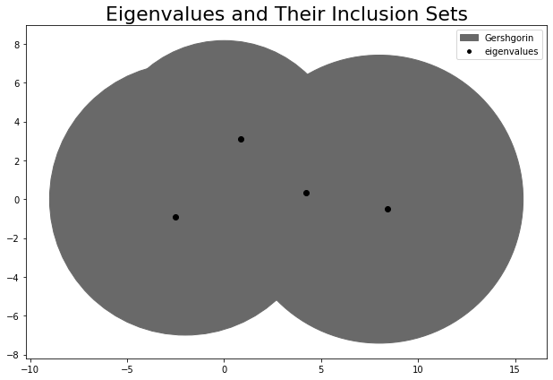

```python
fig, ax = plt.subplots(1, 1, figsize=(12, 6), tight_layout=True)
plt.title('Eigenvalues and Their Inclusion Sets', fontsize=22)


A = np.array([[      8, -1 + 1j,  4, -2],
              [-3 + 1j,      2j,  0,  3],
              [      0,       1, -2, 6j],
              [     -1,      -2,  1,  5]])

plot_sets(A, ax, ['gamma'])
```

### 2. Cassini Ovals (Brauer Set)

$$\Delta^R(A) = \bigcup_{i\neq j}^n \left\{z\in \mathbb{C}: |z - a_{ii}||z - a_{jj}| \leq R'_i(A)R'_j(A)\right\}$$

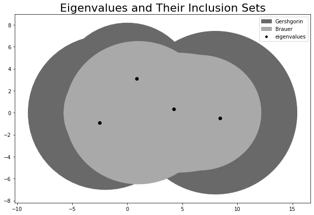

```python
fig, ax = plt.subplots(1, 1, figsize=(12, 6), tight_layout=True)
plt.title('Eigenvalues and Their Inclusion Sets', fontsize=22)


A = np.array([[      8, -1 + 1j,  4, -2],
              [-3 + 1j,      2j,  0,  3],
              [      0,       1, -2, 6j],
              [     -1,      -2,  1,  5]])

plot_sets(A, ax, ['gamma', 'delta'])
```

Ok, but about the following matrix?

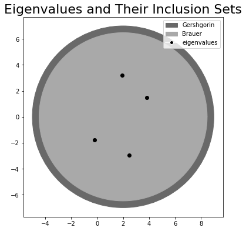

```python
fig, ax = plt.subplots(1, 1, figsize=(6, 6), tight_layout=True)
plt.title('Eigenvalues and Their Inclusion Sets', fontsize=22)

A = np.array([[ 2, 1j, -3, -1j],
              [ 0,  2,  1, -5j],
              [ 4,  1,  2,   2],
              [1j, -1,  1,   2]])

plot_sets(A, ax, ['gamma', 'delta'])
```

### 3*. Cassini Ovals (Melman Set)

Cassini Ovals for matrices with constant main diagonal.

**Main idea:** form $A_0^2$ and utilize Gershgorin Theorem:

$$\Omega^R(A) = \bigcup_{i = 1}^n \left\{z\in \mathbb{C}: |z - \alpha - \sqrt{(A_0^2)_{ii}}||z - \alpha + \sqrt{(A_0^2)_{ii}}| \leq R'_i(A_0^2)\right\},$$

where $\alpha$ is the diagonal element and $A_0 = A - \alpha I$

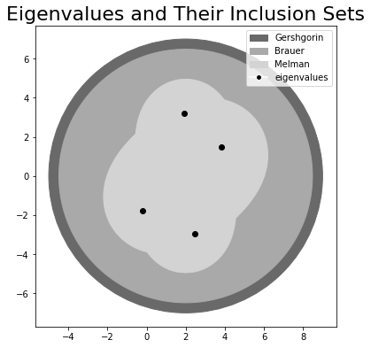

```python
fig, ax = plt.subplots(1, 1, figsize=(6, 6), tight_layout=True)
plt.title('Eigenvalues and Their Inclusion Sets', fontsize=22)

A = np.array([[ 2, 1j, -3, -1j],
              [ 0,  2,  1, -5j],
              [ 4,  1,  2,   2],
              [1j, -1,  1,   2]])

plot_sets(A, ax)
```

Important class of matrices with constant main diagonal are Toeplitz matrices!

$ T = \begin{bmatrix} t_0 & t_1 & \dots & t_{n - 1} \\ t_{-1} & t_0 & \dots & t_{n - 2} \\ \vdots & \vdots & \ddots & \vdots \\ t_{1 - n} & t_{2 - n} & \dots & t_0 \\ \end{bmatrix} $

## II. Melman Set Properties

### 1. Inclusion Sets for Random Band Matrices with a Constant Main Diagonal

Let us denote the radius of the disc containing $\Omega^{R}(A)$ and centred at $\alpha$ by $\rho_{\Omega}$ and the radius of the discs defining $\Gamma^{R}(A)$ and $\Delta^{R}(A)$ by $\rho_{\Gamma}$ and $\rho_{\Delta}$, respectively.

We also denote $\mu = \max_{1 \leq i \leq n} |\lambda_i - \alpha|$, where the $\lambda_i$’s are the eigenvalues of A and $\alpha$ isthe constant diagonal element of A.

Then $$ \rho_{\Omega} \leq \rho_{\Delta} \leq \rho_{\Gamma}$$

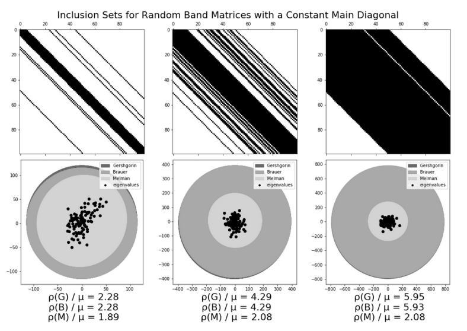

```python
plt.figure(figsize=(20, 10))
plt.imshow(mpimg.imread(f'img/band.png'))
plt.axis('off')
plt.show()
```

### 2. Toeplitz Matrices Dominated by Two Side Diagonals

When the absolute values of the elements in upper diagonal, symmetrically placed lower diagonal, dominate the absolute values of the other elements of the matrix.

The square of such a matrix has a dominant main diagonal. Gershgorin’s discs give the best results for such matrices and since the sets are based on them, we can expect them to work particularly well in these cases.

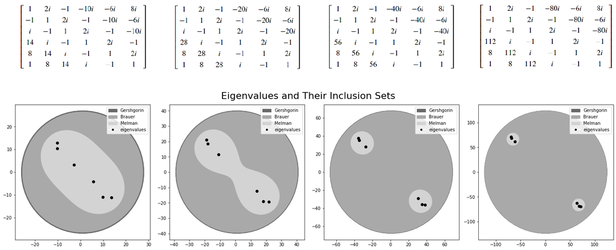

```python
fig, ax = plt.subplots(2, 4, figsize=(20, 10), tight_layout=True)
fig.suptitle('Eigenvalues and Their Inclusion Sets', fontsize=22, y=.55)

for i in range(4):
    r = [1, 2j, -1, -10j * (2 ** i), -6j, 8j]
    c = [1, -1, 1j,   14 * (2 ** i),   8, 1j]

    A = toeplitz(c, r)
    ax[0][i].imshow(mpimg.imread(f'img/m{i+1}.png'))
    ax[0][i].axis('off')
    plot_sets(A, ax[1][i])
```

## III. Applications

### 0. Eigenvalue Spectrum Bounds Estimate

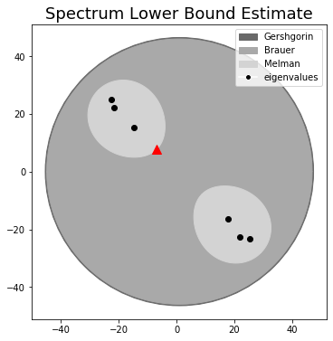

```python
r, c = [1, 2j, -1, -10j*(2**1.3), -6j, 8j], [1, -1, 1j, 14*(2**1.3), 8, 1j]
A = toeplitz(c, r)

ovals = get_melman(A)
min_point, _ = get_nearest_melman(ovals)

fig, ax = plt.subplots(1, 1, figsize=(6, 6))

plot_sets(A, ax)
plt.plot(*min_point, '^', markersize=10, color='red')
plt.title('Spectrum Lower Bound Estimate', fontsize=18)
plt.show()
```

### 1. Inverse Power Iteration

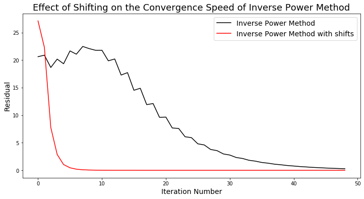

```python
plt.figure(figsize=(12, 6))

plt.plot(res_, color='k', label='Inverse Power Method')
plt.plot(res, color='r', label='Inverse Power Method with shifts')

plt.title('Effect of Shifting on the Convergence Speed of Inverse Power Method', fontsize=18)
plt.ylabel('Residual', fontsize=14)
plt.xlabel('Iteration Number', fontsize=14)

plt.legend(fontsize=14)
plt.show()
```

### 2. QR Algorithm

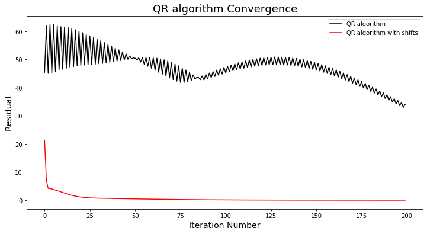

```python
plt.figure(figsize=(12, 6))

plt.plot(deltas_0,  color='k', label='QR algorithm')
plt.plot(deltas,  color='r', label='QR algorithm with shifts')

plt.title('QR algorithm Convergence', fontsize=18)
plt.ylabel('Residual', fontsize=14)
plt.xlabel('Iteration Number', fontsize=14)

plt.legend()
plt.show()
```

## Conclusion

- Matrices with constant main diagonal are quite common, e.g. Toeplitz
- Gershgorin and Brauer sets does not show sufficient about the spectrum in this case
- Melman set as a solution
- Applications: Inverse Power Method and QR algorithm speed-up